# Lab 1

Chris Troeger

January 13, 2022

## Introduction

For the lab demonstration today, we will be using the *MDA_Coverage.csv* file that is posted on Canvas and is part of Homework 1.

### Goals for this session

- Introduction to R Markdown
- Review of basic data management in R
- Plotting and linear regression

## Preparing environment

Data loading and manipulation R has an “environment”. Essentially this means that R can contain a variety of packages, data, and other objects at the same time.

```r
## Libraries
  library("ggplot2")      # Plotting
  library("lme4")         # Mixed-models
  library("data.table")   # Data manipulation
  library("reshape2")     # Data manipulation
  library("knitr")        # Markdown helper
```

You can assign a name to a data frame by the “<-” or “=” sign. I am going to load the data and assign to an object called *dt*.

```r
## Data
# I am reading in the data again later, so I am saving
# a backup
  dt <- read.csv("C:/Users/ctroeger/OneDrive - UW/PhD/GH Teaching Assistant/Data/MDA_Coverage.csv")
  back_up_dt <- dt
```

## Data inspection

There are a few things that we can do to investigate our data. Let’s do some descriptive statistics.

```r
# What are the columns? How are they structured?
  head(dt)
```

```
##   OBJECTID       ADMIN0    ADMIN2 ADMIN2ID COV_99 COV_00 COV_01 COV_02 COV_03
## 1     5484 Burkina Faso    Sapouy      865     65     72     80     NA     89
## 2     5485 Burkina Faso       Leo      852     NA     85     90     90     95
## 3     5487 Burkina Faso  Dedougou      835     NA     67     60     NA     85
## 4     9989 Burkina Faso      Kaya      846     70     79     88     86     99
## 5    11324 Burkina Faso Tenkodogo      873     73     85     82     73     87
## 6    11727 Burkina Faso     Manga      853     79     85     83     89     98
```

```r
  str(dt)
```

```
## 'data.frame':    34 obs. of  9 variables:
##  $ OBJECTID: int  5484 5485 5487 9989 11324 11727 11767 11768 12084 12085 ...
##  $ ADMIN0  : chr  "Burkina Faso" "Burkina Faso" "Burkina Faso" "Burkina Faso" ...
##  $ ADMIN2  : chr  "Sapouy" "Leo" "Dedougou" "Kaya" ...
##  $ ADMIN2ID: int  865 852 835 846 873 853 848 827 840 829 ...
##  $ COV_99  : int  65 NA NA 70 73 79 77 60 68 65 ...
##  $ COV_00  : int  72 85 67 79 85 85 84 80 76 89 ...
##  $ COV_01  : int  80 90 60 88 82 83 NA 84 76 82 ...
##  $ COV_02  : int  NA 90 NA 86 73 89 74 67 NA 75 ...
##  $ COV_03  : int  89 95 85 99 87 98 92 81 88 82 ...
```

```r
# Descriptive statistics
# Often, we will want to learn more about our data before running
# any analyses on them. summary() is a good way to quickly see
# our data
  summary(dt)
```

```
##     OBJECTID        ADMIN0             ADMIN2             ADMIN2ID
##  Min.   : 5484   Length:34          Length:34          Min.   : 826.0
##  1st Qu.:12084   Class :character   Class :character   1st Qu.: 838.5
##  Median :14727   Mode  :character   Mode  :character   Median : 854.0
##  Mean   :14276                                         Mean   : 878.6
##  3rd Qu.:17676                                         3rd Qu.: 870.2
##  Max.   :17684                                         Max.   :1174.0
##
##      COV_99          COV_00          COV_01          COV_02
##  Min.   :60.00   Min.   :67.00   Min.   :60.00   Min.   :62.00
##  1st Qu.:66.00   1st Qu.:76.75   1st Qu.:77.25   1st Qu.:73.00
##  Median :70.00   Median :82.50   Median :79.00   Median :82.00
##  Mean   :69.56   Mean   :81.19   Mean   :80.23   Mean   :79.87
##  3rd Qu.:74.00   3rd Qu.:85.00   3rd Qu.:83.75   3rd Qu.:88.75
##  Max.   :79.00   Max.   :90.00   Max.   :90.00   Max.   :93.00
##  NA's   :7       NA's   :2       NA's   :4       NA's   :4
##      COV_03
##  Min.   : 81.00
##  1st Qu.: 84.25
##  Median : 88.50
##  Mean   : 89.35
##  3rd Qu.: 94.00
##  Max.   :100.00
##
```

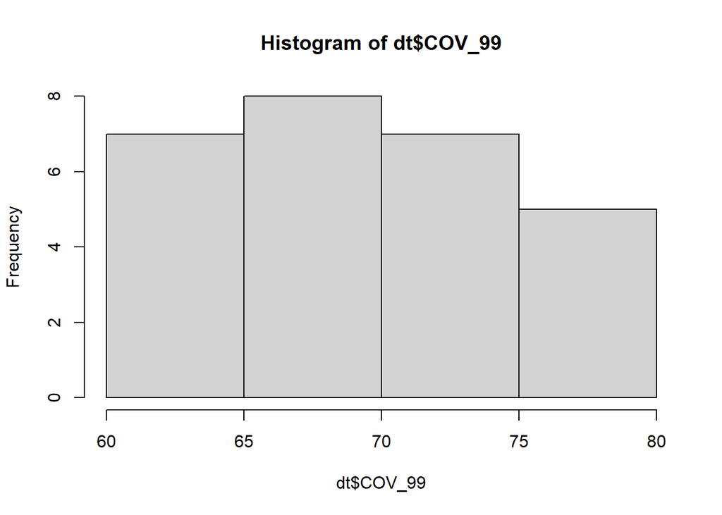

```r
  # Perhaps, we will want to see distributions. Histograms are a good option
  hist(dt$COV_99)
```

```r
  # Or maybe correlations
  cor(dt$COV_99, dt$COV_03) # Why does this return an NA?
```

```
## [1] NA
```

```r
  # It returns an NA because there are missing values in COV_99 and/or COV_03
  cor(dt$COV_99, dt$COV_03, use = "complete.obs")
```

```
## [1] 0.2683202
```

```r
  # cor.test provides p-values and uses complete observations by default
  cor.test(dt$COV_99, dt$COV_03)
```

```
##
##  Pearson's product-moment correlation
##
## data:  dt$COV_99 and dt$COV_03
## t = 1.3927, df = 25, p-value = 0.176
## alternative hypothesis: true correlation is not equal to 0
## 95 percent confidence interval:
##  -0.1243758  0.5883435
## sample estimates:
##       cor
## 0.2683202
```

```r
  # How about a t-test?
  t.test(dt$COV_99, dt$COV_03)
```

```
##
##  Welch Two Sample t-test
##
## data:  dt$COV_99 and dt$COV_03
## t = -13.041, df = 55.819, p-value < 2.2e-16
## alternative hypothesis: true difference in means is not equal to 0
## 95 percent confidence interval:
##  -22.83866 -16.75611
## sample estimates:
## mean of x mean of y
##  69.55556  89.35294
```

For a very basic example, we are going to see if coverage in 2003 (COV_03) can be predicted by coverage in 1999 (COV_99). Let’s do some plots of the distributions. Base R produces plots that Bobby prefers. I (Chris) prefer *ggplot2*, but it has a much different syntax that can be hard to learn.

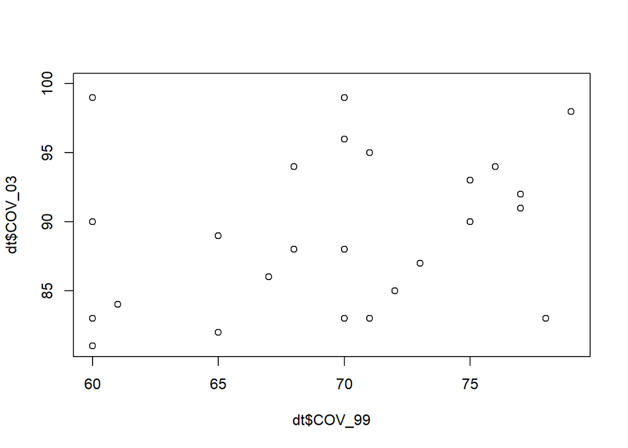

```r
# Base R
  plot(dt$COV_99, dt$COV_03)
```

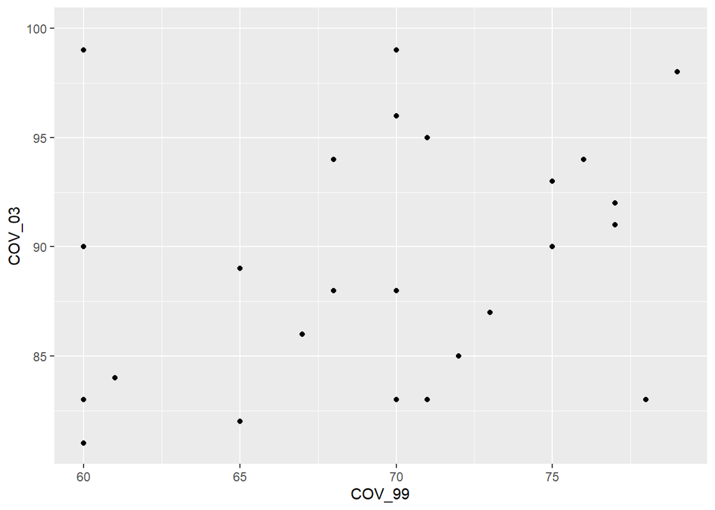

```r
# ggplot2 (my preferred plotting)
  ggplot(dt, aes(x = COV_99, y = COV_03)) + # Uses 'dt' and defines plotting characteristics (aesthetics)
    geom_point()                            # Tells ggplot to make a scatter
```

Hard to tell much. Let’s run a linear model.

## Linear and generalized linear models

A linear model will quantify this relationship for us.

```r
  mod1 <- lm(COV_03 ~ COV_99, data = dt)
  summary(mod1)
```

```
##
## Call:
## lm(formula = COV_03 ~ COV_99, data = dt)
##
## Residuals:
##     Min      1Q  Median      3Q     Max
## -8.2051 -3.3656 -0.7254  3.2746 12.2584
##
## Coefficients:
##             Estimate Std. Error t value Pr(>|t|)
## (Intercept)  71.8632    12.4276   5.783    5e-06 ***
## COV_99        0.2480     0.1781   1.393    0.176
## ---
## Signif. codes:  0 '***' 0.001 '**' 0.01 '*' 0.05 '.' 0.1 ' ' 1
##
## Residual standard error: 5.356 on 25 degrees of freedom
##   (7 observations deleted due to missingness)
## Multiple R-squared:  0.072,  Adjusted R-squared:  0.03488
## F-statistic:  1.94 on 1 and 25 DF,  p-value: 0.176
```

Neat(ish), there is a non-significant positive relationship between coverage in those years.

What if we only cared if coverage in 2003 is greater than 90%? This is kind of a forced example but I want to show a *generalized linear model*

```r
# Is value > 90%?
  dt$high_cov <- ifelse(dt$COV_03 > 90, 1, 0)
  table(dt$high_cov)
```

```
##
##  0  1
## 20 14
```

We have a new variable that is binary. An appropriate model for this outcome is a logistic regression (binomial).

```r
  mod2 <- glm(high_cov ~ COV_99, data = dt, family = "binomial")
  summary(mod2)
```

```
##
## Call:
## glm(formula = high_cov ~ COV_99, family = "binomial", data = dt)
##
## Deviance Residuals:
##     Min       1Q   Median       3Q      Max
## -1.4568  -0.9485  -0.5237   1.0088   2.0913
##
## Coefficients:
##              Estimate Std. Error z value Pr(>|z|)
## (Intercept) -11.08123    5.99841  -1.847   0.0647 .
## COV_99        0.15022    0.08441   1.780   0.0751 .
## ---
## Signif. codes:  0 '***' 0.001 '**' 0.01 '*' 0.05 '.' 0.1 ' ' 1
##
## (Dispersion parameter for binomial family taken to be 1)
##
##     Null deviance: 35.594  on 26  degrees of freedom
## Residual deviance: 31.750  on 25  degrees of freedom
##   (7 observations deleted due to missingness)
## AIC: 35.75
##
## Number of Fisher Scoring iterations: 3
```

How do we interpret these results? Recall that the coefficients from a binomial model are log(odds ratios). So, we can exponentiate.

```r
  odds <- exp(coef(mod2))
  odds
```

```
##  (Intercept)       COV_99
## 1.539874e-05 1.162095e+00
```

So, for each 1 unit increase in coverage in 1999, the odds that coverage in 2003 is greater than 90% increases by 1.16 times.

### Predictions

Recall that making predictions from linear models in R is pretty easy.

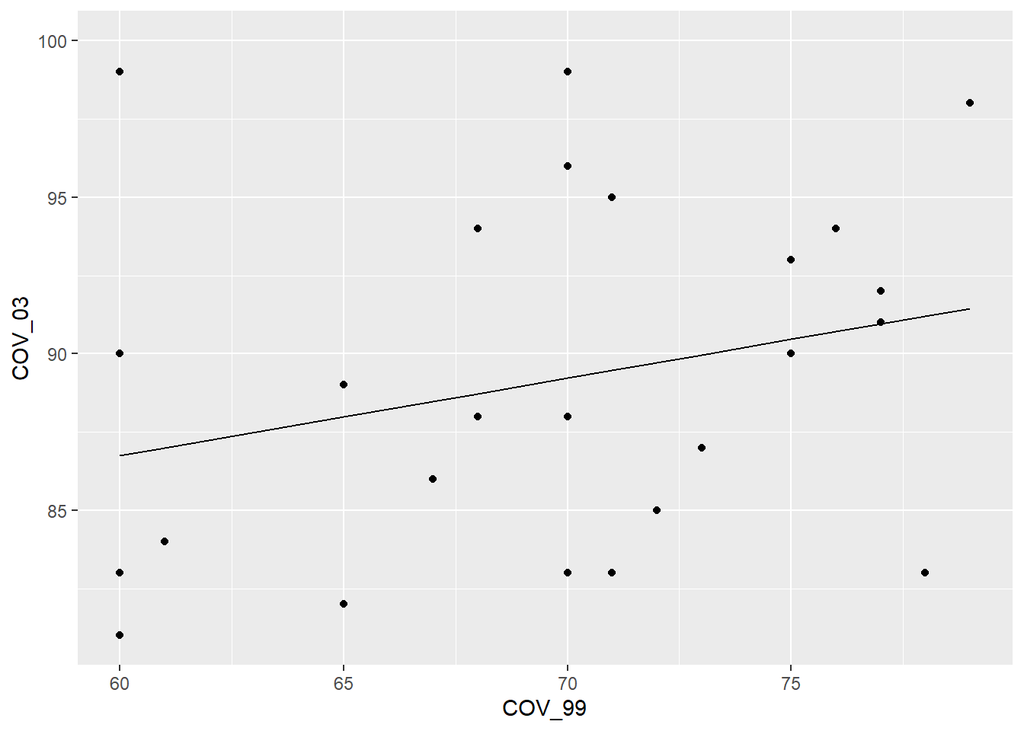

```r
# Make prediction
  dt$pred1 <- predict(mod1, newdata = dt)

# Plot it (won't work so well if there is more than 1 predictor... why?)
  ggplot(dt, aes(x = COV_99, y = COV_03)) + geom_point() + geom_line(aes(y = pred1))
```

ggplot() has a nice shortcut for linear models, the only downside is that you can’t easily see the model summaries (like the coefficients, R^2, etc).

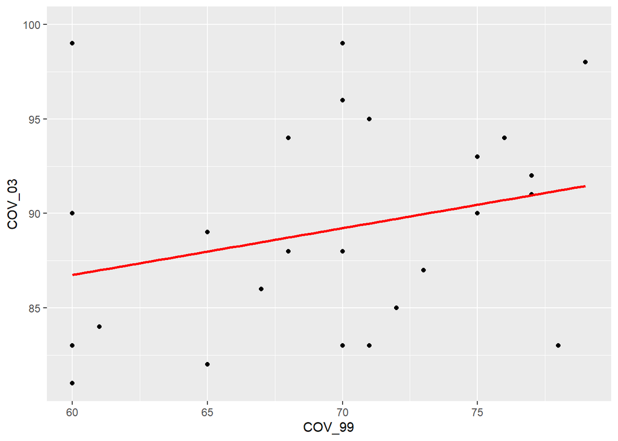

```r
  ggplot(dt, aes(x = COV_99, y = COV_03)) + geom_point() +
      stat_smooth(method = "lm", se = F, col = "red") # lm = linear model, se = F means don't plot predicted standard errors
```

R is not that smart about making predictions from generalized models, however. The modeler (you) must transform back to linear space.

```r
# Predict our binomial model
  dt$pred2 <- predict(mod2, newdata = dt)
  head(dt) # our values are negative!
```

```
##   OBJECTID       ADMIN0    ADMIN2 ADMIN2ID COV_99 COV_00 COV_01 COV_02 COV_03
## 1     5484 Burkina Faso    Sapouy      865     65     72     80     NA     89
## 2     5485 Burkina Faso       Leo      852     NA     85     90     90     95
## 3     5487 Burkina Faso  Dedougou      835     NA     67     60     NA     85
## 4     9989 Burkina Faso      Kaya      846     70     79     88     86     99
## 5    11324 Burkina Faso Tenkodogo      873     73     85     82     73     87
## 6    11727 Burkina Faso     Manga      853     79     85     83     89     98
##   high_cov    pred1      pred2
## 1        0 87.98145 -1.3166213
## 2        1       NA         NA
## 3        0       NA         NA
## 4        1 89.22132 -0.5654979
## 5        0 89.96524 -0.1148239
## 6        1 91.45308  0.7865242
```

```r
# That's because a binomial model logit-transforms the outcome (high_cov) so
# so we must back-transform it (inverse logit).
# There are packages with that function but let's make it ourselves for practice.
  inv_logit <- function(x){
    y <- exp(x) / (1 + exp(x))
    return(y)
  }

  dt$pred2_linear <- inv_logit(dt$pred2)
  head(dt)
```

```
##   OBJECTID       ADMIN0    ADMIN2 ADMIN2ID COV_99 COV_00 COV_01 COV_02 COV_03
## 1     5484 Burkina Faso    Sapouy      865     65     72     80     NA     89
## 2     5485 Burkina Faso       Leo      852     NA     85     90     90     95
## 3     5487 Burkina Faso  Dedougou      835     NA     67     60     NA     85
## 4     9989 Burkina Faso      Kaya      846     70     79     88     86     99
## 5    11324 Burkina Faso Tenkodogo      873     73     85     82     73     87
## 6    11727 Burkina Faso     Manga      853     79     85     83     89     98
##   high_cov    pred1      pred2 pred2_linear
## 1        0 87.98145 -1.3166213    0.2113810
## 2        1       NA         NA           NA
## 3        0       NA         NA           NA
## 4        1 89.22132 -0.5654979    0.3622763
## 5        0 89.96524 -0.1148239    0.4713255
## 6        1 91.45308  0.7865242    0.6870845
```

## Generalized linear mixed models (GLMMs)

Linear mixed models are models that incorporate grouping, clustering, or repeated measurements from a dataset into a statistical regression model. I will try to consistently use the term *hierarchical* to describe data that were generated in this way. *Generalized* is a way to extend linear models to transformed outcomes (log, logit, Poisson, etc). Other names for this model structure are:

- Hierarchical models
- Mixed-effects models
- Random-effects models (random intercepts; random slopes)
- Multi-level models

### Transform our data as a dummy example

These data are actually clustered. We have repeated measurements (coverage) by administrative unit in Burkina Faso. Let’s restructure our data to a *long* format to see them in this way.

```r
# re-assign the data again so I don't have the prediction columns
  dt <- back_up_dt

## For this example, I am going to re-structure the data so they are "long"
  dtl <- melt(dt, id.vars = c("OBJECTID","ADMIN0","ADMIN2","ADMIN2ID"))

## Create a "year" variable
  dtl$year <- substr(dtl$variable, 5, 6) # keep the 5th and 6th characters
  dtl$year <- ifelse(dtl$year == "99", 1999, as.numeric(dtl$year) + 2000)
  head(dtl)
```

```
##   OBJECTID       ADMIN0    ADMIN2 ADMIN2ID variable value year
## 1     5484 Burkina Faso    Sapouy      865   COV_99    65 1999
## 2     5485 Burkina Faso       Leo      852   COV_99    NA 1999
## 3     5487 Burkina Faso  Dedougou      835   COV_99    NA 1999
## 4     9989 Burkina Faso      Kaya      846   COV_99    70 1999
## 5    11324 Burkina Faso Tenkodogo      873   COV_99    73 1999
## 6    11727 Burkina Faso     Manga      853   COV_99    79 1999
```

### Let’s plot these newly reshaped data

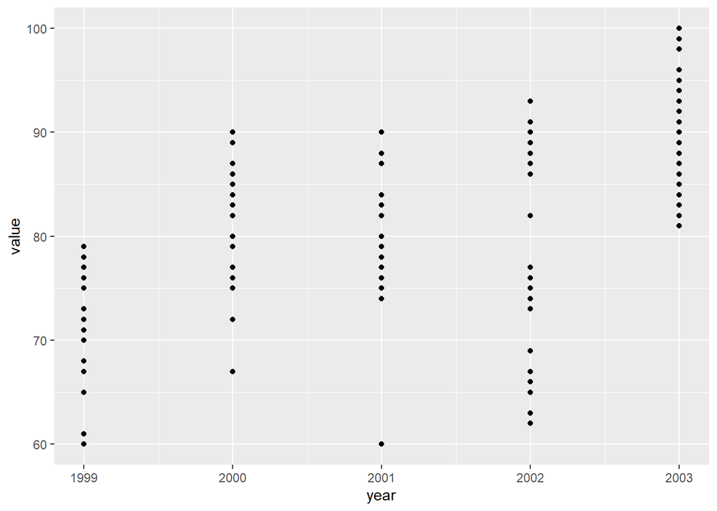

```r
  ggplot(dtl, aes(x = year, y = value)) + geom_point()
```

We know that these data come from repeated observations within administrative units. Let’s plot that. Because there are so many, let’s just plot a few of the administrative units. I am also using a shortcut. *ggplot* has a function (*stat_smooth()*) that can fit linear models to our data.

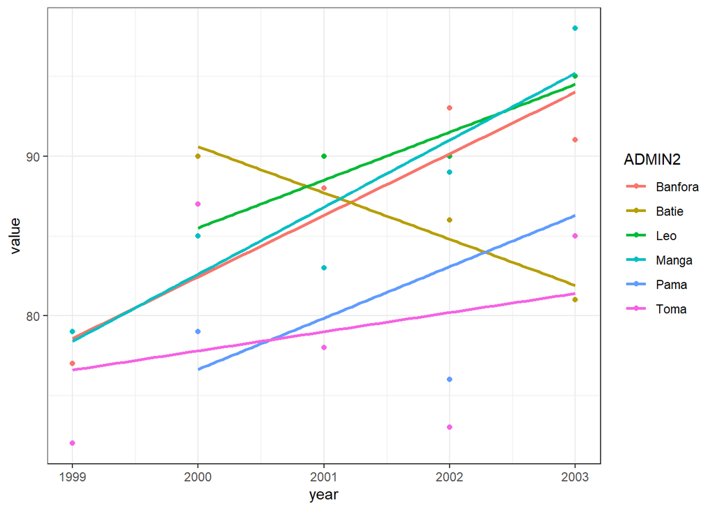

```r
  ggplot(dtl[dtl$ADMIN2 %in% c("Banfora","Batie","Leo","Manga","Pama","Toma"), ],
         aes(x = year, y = value, col = ADMIN2)) + geom_point() +
    theme_bw() +
    stat_smooth(method = "lm", se = F) # fits a linear model, suppresses standard errors
```

From this example, we see that there are clearly different starting places for coverage in 1999 (intercept) and different slopes by year.

Let’s first fit three models:

1. $y_i \sim \beta_0 + \beta_1Year_i + epsilon_i$
2. $y_i \sim \beta_0 + \alpha_{0,j} + \beta_1Year_i + epsilon_i$
3. $y_i \sim \beta_0 + \alpha_{0,j} + (\beta_1 + \gamma_{1,j})Year_i + epsilon_i$

The first model is a linear model that doesn’t account for the repeated observations with an administrative unit. The second model includes a random intercept

$\alpha_{0,j} \sim N(0,\sigma^2_{\alpha})$

The third model includes a random slope and a random intercept.

$$\begin{aligned} \\
\begin{pmatrix}
\alpha_{0,j} \\
\gamma_{1,j}
\end{pmatrix} \sim N \left[ \begin{pmatrix}
0 \\
0
\end{pmatrix},
\begin{pmatrix}
\sigma^2_{\alpha_0} & \rho \sigma_{\alpha_0} \sigma_{\gamma_1}\\
\rho \sigma_{\alpha_0} \sigma_{\gamma_1} & \sigma^2_{\gamma_1}
\end{pmatrix} \right] \\
\end{aligned}$$

We also see quite a few missing values:

```r
  nrow(dtl)
```

```
## [1] 170
```

```r
  nrow(dtl[is.na(dtl$value),])
```

```
## [1] 17
```

What should we do about them? For this demonstration, I am going to use them as an opportunity to create a new dummy variable that indicates if an ADMIN2 has any missing data. The reason I am doing this is to practice with merging datasets, something you will need to do for the homework.

```r
# Find the ADMIN2 areas with missing values
  missing <- dtl[is.na(dtl$value),]

# Some areas have multiple missing values. For this exercise, I want unique areas.
  missing <- missing[, c("ADMIN2", "ADMIN2ID")]
  missing <- unique(missing)

# Create a dummy indicator that this area has missing values
  missing$has_missing <- 1

# Now, use the merge() function to merge back with our data
# Note a few options for merge() that we discussed in lab
# by default, it will only keep rows from the first
# dataframe that have a match in the second
# You can also specify to keep all rows in dataset 1 regardless of matching
# or keep all rows in dataset 2 regardless of matching,
# or finally keep all rows in both datasets (many:many)

# Let's test that
  dtl_1 <- merge(dtl, missing, by = "ADMIN2")
  dtl_m1 <- merge(dtl, missing, by = "ADMIN2", all.x = T)
  dtl_1m <- merge(dtl, missing, by = "ADMIN2", all.y = T)
  dtl_mm <- merge(dtl, missing, by = "ADMIN2", all = T)

# What I want for this example is to keep all ADMIN2 units
# and all rows, in the full dataset
  dtl <- merge(dtl,
               missing,
               by = "ADMIN2", # This is the variable that needs to exist in both datasets to merge with.
               all.x = T)     # If I don't add this, I will lose locations that aren't in 'missing', the
                              # opposite of what I want!



  dtl$has_missing <- ifelse(is.na(dtl$has_missing), 0, 1)
```

```r
  linmod <- lm(value ~ year, data = dtl)
  rintmod <- lmer(value ~ year + (1 | ADMIN2), data = dtl)
  rslpmod <- lmer(value ~ year + (1 + year | ADMIN2), data = dtl) # This is a poor model!
```

```
## boundary (singular) fit: see ?isSingular
```

The last model is Singular! That is **bad**. Don’t use a model that is singular. This means that if you know the value of one parameter, you can nearly perfectly predict another. Let’s see if we can figure out what happened.

```r
  summary(rslpmod)
```

```
## Linear mixed model fit by REML ['lmerMod']
## Formula: value ~ year + (1 + year | ADMIN2)
##    Data: dtl
##
## REML criterion at convergence: 1045.5
##
## Scaled residuals:
##     Min      1Q  Median      3Q     Max
## -2.9380 -0.5363  0.0465  0.7511  1.7782
##
## Random effects:
##  Groups   Name        Variance  Std.Dev. Corr
##  ADMIN2   (Intercept) 5.363e+01 7.323163
##           year        1.744e-05 0.004176 -0.99
##  Residual             5.359e+01 7.320522
## Number of obs: 153, groups:  ADMIN2, 34
##
## Fixed effects:
##               Estimate Std. Error t value
## (Intercept) -7444.7919   839.9282  -8.864
## year            3.7606     0.4197   8.959
##
## Correlation of Fixed Effects:
##      (Intr)
## year -1.000
## optimizer (nloptwrap) convergence code: 0 (OK)
## boundary (singular) fit: see ?isSingular
```

There are two places we should look. First, the correlation of the random effects (intercept and slope on year) has a value of -0.99 (in the Random effects section). Second, the correlation of the fixed effects (intercept and year) is -1.00 (very bottom of output). This is not good for the model! It means that there is an almost perfect negative correlation between intercept and slope. If you know the slope on year, you can perfectly predict the intercept!

Predicting from these models is the same as predicting a linear model

```r
  dtl$predlin <- predict(linmod, newdata = dtl)
  dtl$predrint <- predict(rintmod, newdata = dtl)
  dtl$predrslp <- predict(rslpmod, newdata = dtl)
```

If we try to plot this, we get something that is probably not what we expected to see

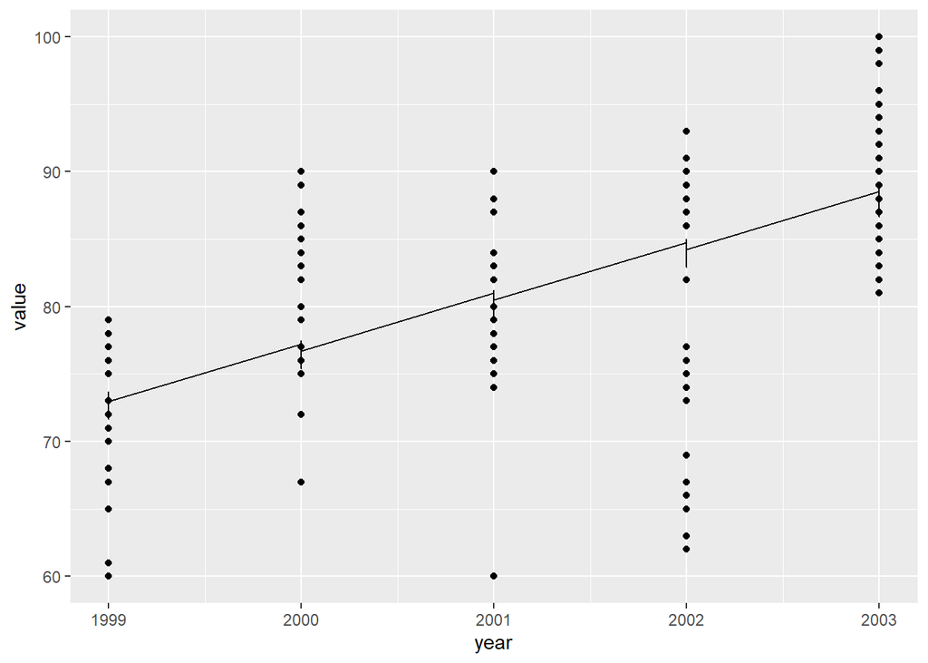

```r
  ggplot(dtl, aes(x = year, y = value)) + geom_point() +
      geom_line(aes(y = predrslp))
```

We must tell ggplot that the lines are part of different “grouping” variable (think of this like our clusters)

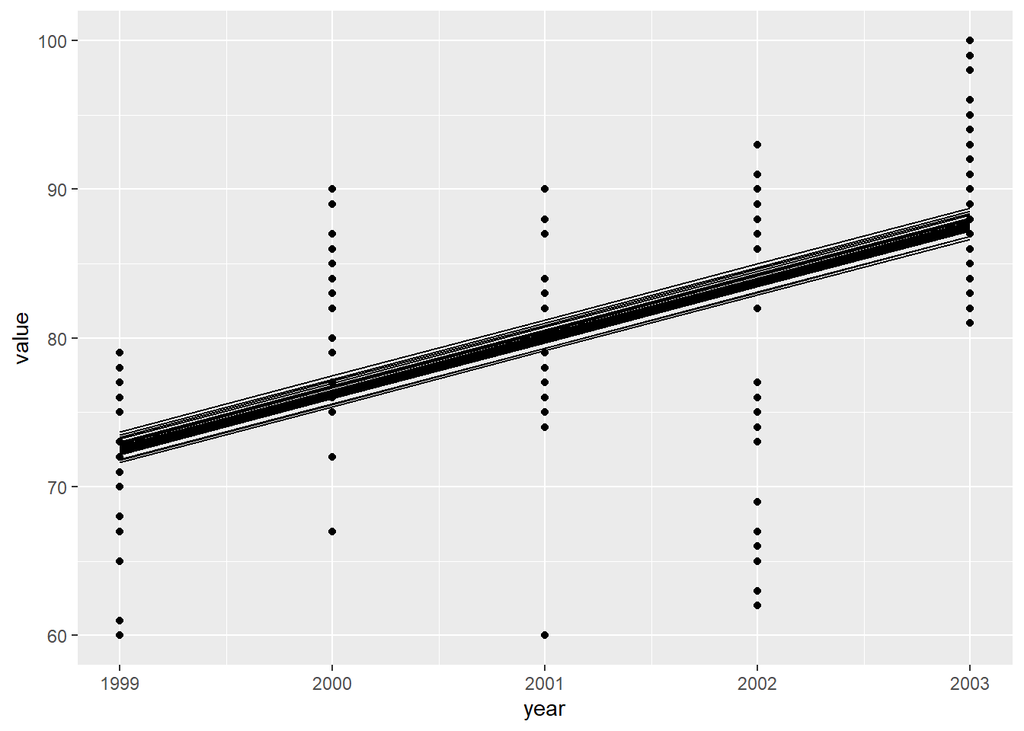

```r
  ggplot(dtl, aes(x = year, y = value)) + geom_point() +
      geom_line(aes(y = predrslp, group = ADMIN2))
```

There we go! However, even when we allow for random slopes, the slopes are nearly all identical (recall that this model has some fundamental problem related to the correlation in year and intercept so most mixed-effects models won’t look like this).

We might be interested in the overall prediction, something that we couldn’t easily see from that plot above. So, often in a GLMM model, we are not interested in individual groups (ADMIN2), we are interested in the overall fit. We can create a skeleton dataframe:

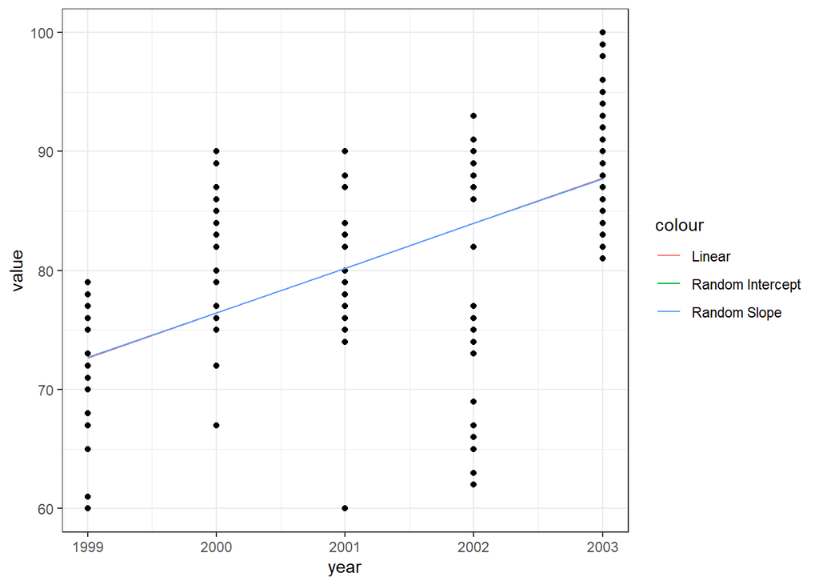

```r
  mm_pred <- data.frame(year = unique(dtl$year),
                        ADMIN2 = "New") # If you tell it an existing ADMIN2, you will get the prediction
                                        # including the random effects
  mm_pred$predlin <- predict(linmod, newdata = mm_pred)

# new.levels are random effect groups that don't exist in the original dataset. These
# groups will be predicted with the overall intercept and slope
  mm_pred$predrint <- predict(rintmod, newdata = mm_pred, allow.new.levels = T)
  mm_pred$predrslp <- predict(rslpmod, newdata = mm_pred, allow.new.levels = T)

# Complicated ggplot to see results
  ggplot(mm_pred, aes(x = year)) +
    geom_point(data = dtl, aes(x = year, y = value)) +
    geom_line(aes(y = predlin, col = "Linear")) +
    geom_line(aes(y = predrint, col = "Random Intercept")) +
    geom_line(aes(y = predrslp, col = "Random Slope")) +
    theme_bw()
```

The model fits are nearly identical.

We can extract information from this model using *coef()* and *fixef()*.

```r
  coef(linmod)
```

```
##  (Intercept)         year
## -7475.953722     3.776192
```

```r
  fixef(rintmod)
```

```
##  (Intercept)         year
## -7445.377457     3.760916
```

```r
  fixef(rslpmod)
```

```
##  (Intercept)         year
## -7444.791881     3.760623
```

The coefficient on $\beta_1$, for year, hardly changed between the models. What about the standard error of the estimate?

```r
# We can get that from the summaries
# kable() is a nice function to produce tables
# kable() will print a dataframe so I am
# artificially creating one by rbind() the
# coefficients from the models.
  kable(rbind(summary(linmod)$coefficients[2,1:3],
              summary(rintmod)$coefficients[2,],
              summary(rslpmod)$coefficients[2,]),
        caption = "Coefficients for year")
```

Coefficients for year

| Estimate | Std. Error | t value |
| --- | --- | --- |
| 3.776192 | 0.4265280 | 8.853329 |
| 3.760916 | 0.4198932 | 8.956840 |
| 3.760623 | 0.4197373 | 8.959470 |

```r
# Or we can get that from the variance-covariance matrix
# A variance covariance matrix has the variance within
# coefficients in a model in the "diagonal". So we use
# the function diag() in R. However, that is the variance
# (thus the name) but the standard error of the estimate
# is more often reported, so we take the square root of that
# sqrt(). Lastly, I want to report the standard error of
# the beta on year, so I ask for the second observation
# (the first observation would be the standard error of
# the intercept term).
# vcov() prints the variance-covariance matrix
  vcov(linmod)
```

```
##             (Intercept)         year
## (Intercept) 728489.7919 -364.0484139
## year          -364.0484    0.1819261
```

```r
  lin_se <- sqrt(diag(vcov(linmod)))[2]
  print(paste0("The standard error on year for the linear model is: ",
               round(lin_se, 2)))
```

```
## [1] "The standard error on year for the linear model is: 0.43"
```

The last potentially useful thing would be to determine which of these models is “best”

```r
AIC(linmod, rintmod, rslpmod)
```

```
##         df      AIC
## linmod   3 1052.684
## rintmod  4 1053.479
## rslpmod  6 1057.478
```

```r
BIC(linmod, rintmod, rslpmod)
```

```
##         df      BIC
## linmod   3 1061.775
## rintmod  4 1065.601
## rslpmod  6 1075.661
```

The goodness of fit statistics suggest that the linear model is best!

## End! I think you have the tools to do Homework 1 now!